# Statistics training

## Linear model trained with all available variables

```r
model_4 <- lm(age_years ~ . , data=data)
summary(model_4)
```

```
Call:
lm(formula = age_years ~ ., data = data)

Residuals:
    Min      1Q  Median      3Q     Max
-23.997  -6.094  -1.143   4.430  37.002

Coefficients:
                                                                                  Estimate Std. Error t value Pr(>|t|)
(Intercept)                                                                     46.5119689  9.7162911   4.787 2.97e-06 ***
checking_account>= 102 euro                                                      4.9409939  2.8949580   1.707 0.089166 .
checking_account0 <= ... <  102 euro                                             2.6235471  1.8238123   1.438 0.151602
checking_accountNo checking account                                              0.9736155  1.7568815   0.554 0.579979
duration_months                                                                 -0.0420841  0.0714898  -0.589 0.556637
credit_historycritical account/other credits existing (not at this bank)        -0.2897856  3.0947428  -0.094 0.925475
credit_historydelay in paying off in the past                                   -0.3690925  3.4730302  -0.106 0.915454
credit_historyexisting credits paid back duly till now                          -0.8419646  2.7114881  -0.311 0.756438
credit_historyno credits taken/ all credits paid back duly                      -3.4205421  3.9169159  -0.873 0.383390
purposecar (new)                                                                -2.4470204  2.8820646  -0.849 0.396702
purposecar (used)                                                               -5.6001768  3.0798895  -1.818 0.070269 .
purposedomestic appliances                                                      -4.5512471  7.7973321  -0.584 0.559977
purposeeducation                                                                -5.0269436  3.3615404  -1.495 0.136122
purposefurniture/equipment                                                      -5.9308474  2.9788001  -1.991 0.047618 *
purposeothers                                                                   -7.6157087  6.0262326  -1.264 0.207548
purposeradio/television                                                         -4.5108528  3.0057391  -1.501 0.134741
purposerepairs                                                                  -0.3543760  5.5204469  -0.064 0.948870
purposeretraining                                                               -7.6989875 11.0055742  -0.700 0.484887
credit_amount                                                                    0.0006084  0.0003236   1.880 0.061331 .
savings... <  51 euro                                                            0.6409387  3.4056254   0.188 0.850880
savings255 euro <= ... < 511 euro                                                2.8534807  4.1354012   0.690 0.490855
savings51 <= ... <  255 euro                                                    -2.7860352  3.8500351  -0.724 0.469995
savingsunknown/ no savings account                                              -0.7746802  3.6152108  -0.214 0.830509
present_employment_since... < 1 year                                            -9.6301264  2.1542166  -4.470 1.21e-05 ***
present_employment_since1  <= ... < 4 years                                     -7.2244691  1.8297678  -3.948 0.000104 ***
present_employment_since4  <= ... < 7 years                                     -9.5769977  2.2066510  -4.340 2.10e-05 ***
present_employment_sinceunemployed                                              -5.8093698  3.0074870  -1.932 0.054587 .
installment_rate                                                                 1.4746358  0.6714775   2.196 0.029046 *
personal_status_sexmale   : divorced/separated                                   7.8932204  3.7247901   2.119 0.035113 *
personal_status_sexmale   : married/widowed                                     -0.7606755  2.5462739  -0.299 0.765398
personal_status_sexmale   : single                                               0.8774392  1.6662667   0.527 0.598967
```

[output cut: 8 more lines]

```
housingrent                                                                     -9.8860124  2.6381793  -3.747 0.000224 ***
existing_credits                                                                 2.0361378  1.4199477   1.434 0.152893
jobskilled employee / official                                                  -2.7446826  2.0435098  -1.343 0.180507
jobunemployed/ unskilled  - non-resident                                         1.5539991  4.7722160   0.326 0.744986
jobunskilled - resident                                                         -1.0913350  2.6338341  -0.414 0.678988
people_liable_maintenance                                                        1.3746136  1.9145955   0.718 0.473480
telephoneyes, registered under the customers name                                0.4116932  1.4980228   0.275 0.783689
foreign_workeryes                                                               -4.5281103  4.1711507  -1.086 0.278759
response                                                                        -1.7492028  1.5878754  -1.102 0.271744
---
Signif. codes:  0 ‘***’ 0.001 ‘**’ 0.01 ‘*’ 0.05 ‘.’ 0.1 ‘ ’ 1

Residual standard error: 10.04 on 239 degrees of freedom
Multiple R-squared:  0.4814,    Adjusted R-squared:  0.3794
F-statistic:  4.72 on 47 and 239 DF,  p-value: 6.178e-16
```

## Additional background information: Find relationship between `purpose` and `credit_amount`

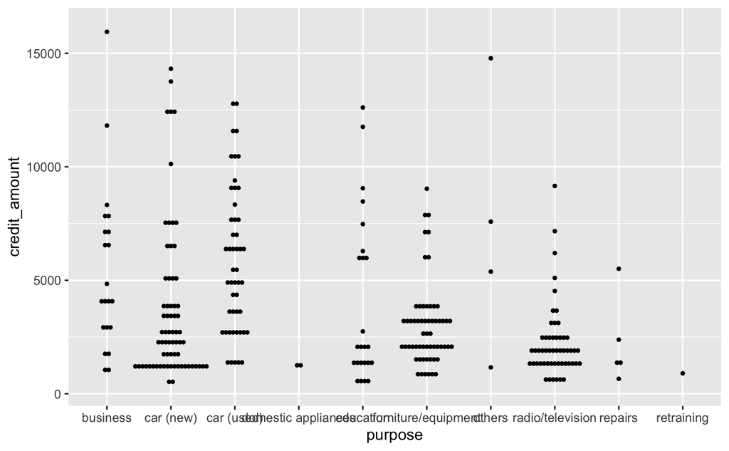

```r
plot_purpose_credit_amount <- ggplot(data = data,
                                     aes(x = purpose,
                                         y = credit_amount))

plot_purpose_credit_amount + geom_dotplot(binaxis='y',
                                          stackdir='center',
                                          dotsize=0.3)
```

### Feature engineering: Creating own/calculated columns/variable (smart)

```r
data$car_loan <- ifelse(data$purpose %in% c("car (new)", "car (used)"), "yes", "no")
```

Create a new model with the new variabele

```r
model_5 <- lm(credit_amount ~ duration_months + job + car_loan, data = data)
summary(model_5)
```

```
Call:
lm(formula = credit_amount ~ duration_months + job + car_loan,
    data = data)

Residuals:
    Min      1Q  Median      3Q     Max
-4914.5 -1401.0  -271.9   766.8  8405.4

Coefficients:
                                         Estimate Std. Error t value Pr(>|t|)
(Intercept)                               1829.05     425.71   4.296 2.39e-05 ***
duration_months                            139.96      10.29  13.606  < 2e-16 ***
jobskilled employee / official           -1847.06     353.97  -5.218 3.52e-07 ***
jobunemployed/ unskilled  - non-resident -2486.05     817.63  -3.041 0.002584 **
jobunskilled - resident                  -2258.33     461.11  -4.898 1.64e-06 ***
car_loanyes                               1033.29     274.36   3.766 0.000202 ***
---
Signif. codes:  0 ‘***’ 0.001 ‘**’ 0.01 ‘*’ 0.05 ‘.’ 0.1 ‘ ’ 1

Residual standard error: 2260 on 281 degrees of freedom
Multiple R-squared:   0.49, Adjusted R-squared:  0.4809
F-statistic: 53.99 on 5 and 281 DF,  p-value: < 2.2e-16
```

### Look for relationships between `age_years`, `housing` and `credit_amount`

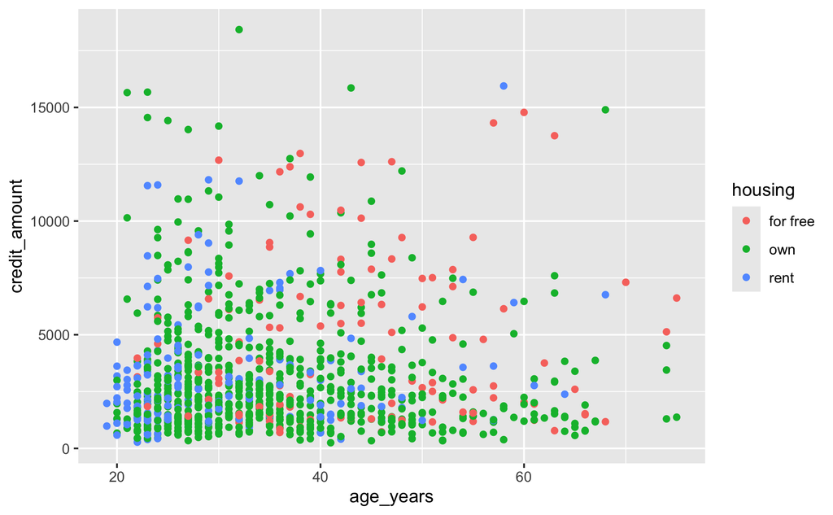

```r
plot_age_years_housing <- ggplot(data = data,
                                 aes(x = age_years,
                                     y = credit_amount))

plot_age_years_housing + geom_point(aes(colour=housing))
```

```r
data$rent_house_low_age <- ifelse(data$housing == "rent" &
                                 data$age_years < 40,
                                 "yes",
                                 "no")
```

```r
model_6 <- lm(credit_amount ~ duration_months + job + car_loan + rent_house_low_age,
              data = data)

summary(model_6)
```

```
Call:
lm(formula = credit_amount ~ duration_months + job + car_loan +
    rent_house_low_age, data = data)

Residuals:
    Min      1Q  Median      3Q     Max
-4686.2 -1172.9  -311.5   780.7 13129.8

Coefficients:
                                         Estimate Std. Error t value Pr(>|t|)
(Intercept)                               1645.54     234.34   7.022 4.05e-12 ***
duration_months                            138.71       5.63  24.640  < 2e-16 ***
jobskilled employee / official           -1746.60     193.81  -9.012  < 2e-16 ***
jobunemployed/ unskilled  - non-resident -1668.99     480.43  -3.474 0.000535 ***
jobunskilled - resident                  -1798.19     232.79  -7.725 2.73e-14 ***
car_loanyes                                616.40     141.28   4.363 1.42e-05 ***
rent_house_low_ageyes                      104.78     188.35   0.556 0.578120
---
Signif. codes:  0 ‘***’ 0.001 ‘**’ 0.01 ‘*’ 0.05 ‘.’ 0.1 ‘ ’ 1

Residual standard error: 2091 on 993 degrees of freedom
Multiple R-squared:  0.4544,    Adjusted R-squared:  0.4511
F-statistic: 137.8 on 6 and 993 DF,  p-value: < 2.2e-16
```

## Extra: Machine Learning

Create the input data frame for new predictions

```r
df_new_data <- data.frame(
  duration_months = data$duration_months,
  job = data$job,
  car_loan = data$car_loan
)
```

Generate the predictions

```r
predictions <- predict.lm(model_5, newdata = df_new_data)

# add the predictions next to the real data
df_preds_actual <- data.frame(
  prediction = predictions,
  actual = data$credit_amount
) %>%
  mutate(delta = abs(prediction - actual))
```

MAE: Mean Absolute error

```r
mean(df_preds_actual$delta)
```

```
[1] 1503.905
```

Percentage

```r
(sum(abs(df_preds_actual$actual - df_preds_actual$prediction) / df_preds_actual$actual)  * 100 ) / nrow(df_preds_actual)
```

```
[1] 66.33129
```

# Logistic Regression

## One variable

```r
model_7 <- glm(response ~ age_years,
               family = "binomial",
               data = data)

summary(model_7)
```

```
Call:
glm(formula = response ~ age_years, family = "binomial", data = data)

Coefficients:
             Estimate Std. Error z value Pr(>|z|)
(Intercept) -0.200919   0.232853  -0.863  0.38822
age_years   -0.018440   0.006434  -2.866  0.00416 **
---
Signif. codes:  0 ‘***’ 0.001 ‘**’ 0.01 ‘*’ 0.05 ‘.’ 0.1 ‘ ’ 1

(Dispersion parameter for binomial family taken to be 1)

    Null deviance: 1221.7  on 999  degrees of freedom
Residual deviance: 1213.1  on 998  degrees of freedom
AIC: 1217.1

Number of Fisher Scoring iterations: 4
```

```r
model_7 <- glm(response ~ age_years + duration_months  + car_loan,
               family = "binomial",
               data = data)

summary(model_7)
```

```
Call:
glm(formula = response ~ age_years + duration_months + car_loan,
    family = "binomial", data = data)

Coefficients:
                Estimate Std. Error z value Pr(>|z|)
(Intercept)     -1.05555    0.27228  -3.877 0.000106 ***
age_years       -0.01902    0.00669  -2.843 0.004470 **
duration_months  0.03756    0.00574   6.543 6.03e-11 ***
car_loanyes      0.15910    0.15008   1.060 0.289087
---
Signif. codes:  0 ‘***’ 0.001 ‘**’ 0.01 ‘*’ 0.05 ‘.’ 0.1 ‘ ’ 1

(Dispersion parameter for binomial family taken to be 1)

    Null deviance: 1221.7  on 999  degrees of freedom
Residual deviance: 1168.1  on 996  degrees of freedom
AIC: 1176.1

Number of Fisher Scoring iterations: 4
```

### Generating predictions

40 years old

duration: 30

car loan is “yes”

```r
-1.05555 + (40 * -0.01902) + (30 * 0.03756) + 0.15910
```

```
[1] -0.53045
```

```r
predict(model_7, newdata = list(age_years=40,
                                duration_months=30,
                                car_loan="yes"),
            type="response")
```

```
        1
0.3703867
```

```r
predictions <- predict(model_7, newdata = data, type="response")
head(predictions)
```

```
        1         2         3         4         5         6
0.1086534 0.5814495 0.1769914 0.4172482 0.2683201 0.4087299
```

Place the predictions next to response

```r
df_predictions <- data.frame(
  actual = data$response,
  prediction_prob = predictions,
  prediction = ifelse(predictions > 0.5, 1, 0)
)

head(df_predictions)
```

|  | actual | prediction_prob | prediction |
| --- | --- | --- | --- |
| 1 | 0 | 0.1086534 | 0 |
| 2 | 1 | 0.5814495 | 1 |
| 3 | 0 | 0.1769914 | 0 |
| 4 | 0 | 0.4172482 | 0 |
| 5 | 1 | 0.2683201 | 0 |
| 6 | 0 | 0.4087299 | 0 |

### Add TP, FP, TN, FN

```r
df_predictions$pred <- ifelse(df_predictions$actual == 0 & df_predictions$prediction == 0, "TN",
                         ifelse(df_predictions$actual == 1 & df_predictions$prediction == 1, "TP",
                                ifelse(df_predictions$actual == 1 & df_predictions$prediction == 0, "FN", "FP")))
```

```r
table(df_predictions$pred)
```

```
 FN  FP  TN  TP
266  25 675  34
```

Metrics to judge the model

- Accuracy
  - TP + TN / TP + TN + FP + FN

```r
(34 + 675) / sum(table(df_predictions$pred))
```

```
[1] 0.709
```

```r
table(data$response)
```

```
  0   1
700 300
```

Sensitivity: If the real value is positive, how good is our model able to find it?

- TP / (TP + FN)

```r
34 / (34 + 266)
```

Precision: If the model predicts positive, how likely is this right?

- TP / (TP + FP)

```r
34 / (34 + 25)
```

Specificity:

TN / (TN + FP)

```r
675 / (675 + 25)
```

https://medium.com/@saurabhdhandeblog/confusion-matrix-explained-calculating-accuracy-tpr-fpr-tnr-precision-and-prevalence-87557fe8714d